# 单细胞配对数据运行教程

XuanLiang

Compiled: June 30, 2025

在本教程中，主要讲述如何根据现有的配对的scRNA-seq和scATAC-seq数据，整合成为配对的Seurat对象，使用官方推荐的Seurat和Signac软件运行。这里以癌症配对的数据中BRCA的样本HT497B1-S1H1为例，官方的教程可以参考文档：https://stuartlab.org/signac/articles/pbmc_multiomic。

**注意**：由于`SCTransform`的随机性，特别是在生成`scale.data`时，运行代码产生的UMAP embedding每次可能都不同。

## 加载所需要的包

- 安装Signac压缩包：`devtools::install_github("timoast/signac", ref = "develop")`。如果遇到任何问题，请查看[Signac文档](https://stuartlab.org/signac/)。
- 安装Seurat压缩包：`install.packages('Seurat')`。如果遇到任何问题，请查看[Seurat文档](https://satijalab.org/seurat/articles/install_v5)。

```r
library(Seurat)
library(ggplot2)
library(patchwork)
library(dplyr)
library(Signac)
library(GenomicRanges)
library(GenomeInfoDb)
library(EnsDb.Hsapiens.v86)
```

## 准备数据

- 使用Seurat包中的`Read10X()`，指定的data.dir中的文件名必须是barcodes.tsv.gz，features.tsv.gz和matrix.mtx.gz。
- 使用Signac包时进行`CallPeaks()`、`TSSEnrichment()`等必须要有.tbi文件。可以按照下面的代码生成.tbi文件：

```bash
# 在建立索引之前，请确保已安装tabix。您可以通过Conda安装它: conda install bioconda::tabix
tabix -0 -p bed HT497B1-S1H1-atac_fragments.tsv.gz
```

## 使用RNA和ATAC数据创建多组学Seurat对象

构建一个Seurat对象，结合RNA表达和ATAC-seq染色质可及性数据以及hg38的基因组特征。

```r
# 从10X Genomics输出文件加载RNA和ATAC数据
counts <- Read10X(data.dir = "HT497B1")
fragpath <- "HT497B1/HT497B1-S1H1-atac_fragments.tsv.gz"
```

```r
# 从EnsDb.Hsapiens.v86获取基因注释
# 在染色体名称前添加“chr”前缀，以匹配峰值命名约定
annotation <- GetGRangesFromEnsDb(ensdb = EnsDb.Hsapiens.v86)
seqlevels(annotation) <- paste0("chr", seqlevels(annotation))

# 创建一个包含RNA计数矩阵的Seurat对象（名为“RNA”的分析）
cancer <- CreateSeuratObject(
  counts = counts$`Gene Expression`,
  assay = "RNA"
)

# 使用过滤后的峰值计数和注释创建ATAC分析，并将其添加到Seurat对象中
cancer[["ATAC"]] <- CreateChromatinAssay(
  counts = counts$Peaks,
  sep = c(":", "-"),
  fragments = fragpath,
  annotation = annotation
)
```

```r
# 展示Seurat对象
cancer
```

```
## An object of class Seurat
## 138599 features across 637990 samples within 2 assays
## Active assay: RNA (36601 features, 0 variable features)
##  1 layer present: counts
##  1 other assay present: ATAC
```

**barcode与fragment不符合的情况**

```r
# 统计每个细胞的ATAC片段数量（即fragment数）
total_counts <- CountFragments(fragpath)

# 找出在total_counts中的细胞条形码（CB）与RNA数据中匹配的细胞索引
ID<-which(counts[["Gene Expression"]]@Dimnames[[2]]%in%total_counts$CB)

# 创建Seurat对象，只包含匹配ID的RNA数据（即与ATAC fragments数据中存在的细胞）
cancer <- CreateSeuratObject(
  counts = counts$`Gene Expression`[,ID],
  assay = "RNA"
)

# 将ATAC数据作为一个新的assay添加到Seurat对象中，只包含匹配ID的ATAC数据。
cancer[["ATAC"]] <- CreateChromatinAssay(
  counts = counts$Peaks[,ID],
  sep = c(":", "-"),
  fragments = fragpath,
  annotation = annotation
)
```

## 质量控制和过滤

计算质量控制指标（nFeature_RNA、nCount_RNA、percent.mt、nCount_ATAC、blacklist_ratio、nucleosome_signal、TSS.enrichment），并使用文章定义的阈值过滤低质量细胞。

- RNA相关的质量控制指标含义，参考[文档](https://satijalab.org/seurat/articles/pbmc3k_tutorial#qc-and-selecting-cells-for-further-analysis)
- ATAC相关的质量控制含义，参考[文档](https://stuartlab.org/signac/articles/pbmc_vignette#computing-qc-metrics)

```r
# 计算线粒体基因表达百分比（在RNA测序中常用于判断细胞质量）
cancer$percent.mt <- PercentageFeatureSet(cancer, pattern = "^MT-", assay = "RNA")

# 设置当前分析对象为 ATAC 模态
DefaultAssay(cancer) <- "ATAC"

# 计算核小体信号（Nucleosome signal），用于评估ATAC数据质量
cancer <- NucleosomeSignal(cancer)

# 计算TSS（转录起始位点）富集程度，用于衡量染色质开放性
cancer <- TSSEnrichment(cancer)

# 计算每个细胞中 ATAC 片段落入 blacklist 区域的比例
cancer$blacklist_ratio <- FractionCountsInRegion(
  object = cancer,
  assay = 'ATAC',
  regions = blacklist_hg38_unified # GRanges对象，定义了ENCODE hg38黑名单区域
)

# 根据多个质量控制指标筛选高质量的细胞
cancer <- subset(cancer, subset =
                   nFeature_RNA > 200 &
                   nFeature_RNA < 10000 &
                   nCount_RNA > 1000 &
                   nCount_RNA < 80000 &
                   percent.mt < 10 &
                   nCount_ATAC > 1000 &
                   nCount_ATAC < 20000 &
                   blacklist_ratio < 0.05 &
                   nucleosome_signal < 5 &
                   TSS.enrichment > 2

)
```

```r
# 展示过滤后的Seurat对象
cancer
```

```
## An object of class Seurat
## 138599 features across 3692 samples within 2 assays
## Active assay: ATAC (101998 features, 0 variable features)
##  2 layers present: counts, data
##  1 other assay present: RNA
```

## 峰值调用和量化

调用峰值、过滤、计数每个峰值的片段，并添加到Seurat对象中

```r
# 使用MACS2从Seurat对象中的片段调用峰值
peaks <- CallPeaks(cancer)

# 去除非标准染色体和基因组黑名单区域中的峰
peaks <- keepStandardChromosomes(peaks, pruning.mode = "coarse")
peaks <- subsetByOverlaps(x = peaks, ranges = blacklist_hg38_unified, invert = TRUE)

# matrix量化每个细胞中与每个峰值重叠的片段计数，创建一个peak-by-cell数矩阵
macs2_counts <- FeatureMatrix(
  fragments = Fragments(cancer),
  features = peaks,
  cells = colnames(cancer)
)
```

```
## Extracting reads overlapping genomic regions
```

```r
# 基于MACS2创建一个新的染色质分析，称为"peaks"，并将其添加到Seurat对象中
cancer[["peaks"]] <- CreateChromatinAssay(
  counts = macs2_counts,
  fragments = fragpath,
  annotation = annotation
)
```

```
## Computing hash
```

```r
# 显示更新的Seurat对象
cancer
```

```
## An object of class Seurat
## 273490 features across 3692 samples within 3 assays
## Active assay: ATAC (101998 features, 0 variable features)
##  2 layers present: counts, data
##  2 other assays present: RNA, peaks
```

## RNA分析

使用SCTransform对RNA数据进行归一化，并执行PCA以进行降维。

```r
# 将默认设置为“RNA”进行基于RNA的分析
DefaultAssay(cancer) <- "RNA"

# 使用SCTransform执行归一化和方差稳定
# 取代了传统的log-normalization，识别高变基因和归一化数据，即代替了原来的三个函数：NormalizeData(), FindVariableFeatures(), ScaleData(),并将处理后的数据存放在“SCT”分析中
cancer <- SCTransform(cancer,vars.to.regress = c("nCount_RNA",
                                                 "percent.mt"), return.only.var.genes = F)

# 对归一化数据运行主成分分析（PCA）
# PCA在保留主要变异源的同时降低了维度
cancer <- RunPCA(cancer)
```

## ATAC分析

识别高度可访问的峰值，并使用TF-IDF和SVD（LSI）进行降维。

```r
# 将默认测定设置为“peaks”
DefaultAssay(cancer) <- "peaks"

# 根据可访问性确定顶部特征（峰值）
cancer <- FindTopFeatures(cancer)

# 执行词频反向文档频率（TF-IDF）规范化
cancer <- RunTFIDF(cancer)

# 使用奇异值分解（SVD）进行降维，在这种情况下也称为潜在语义索引（LSI）
cancer <- RunSVD(cancer)
```

### 整合分析

使用[Seurat v4](https://www.biorxiv.org/content/10.1101/2020.10.12.335331v1)在加权最近邻方法中，我们将基因表达和染色质可及性整合到联合邻居图中，并结合RNA和ATAC数据创建统一的UMAP embedding。

```r
# 使用RNA的PCA和ATAC的LSI构建模态最近邻图
cancer <- FindMultiModalNeighbors(
  object = cancer,
  reduction.list = list("pca", "lsi"),
  dims.list = list(1:30, 2:30),
  modality.weight.name = "RNA.weight",
  verbose = TRUE
)

# 使用WNN图生成UMAP embedding
# embedding结合了RNA和ATAC模态的信息
cancer <- RunUMAP(
  object = cancer,
  nn.name = "weighted.nn",
  assay = "RNA",
  verbose = TRUE
)
```

## 细胞聚类与UMAP可视化

使用SCT标准化的表达数据，基于前30个主成分构建邻接图并进行聚类，随后通过UMAP进行降维和可视化。

**注意**：这里未进行细胞注释

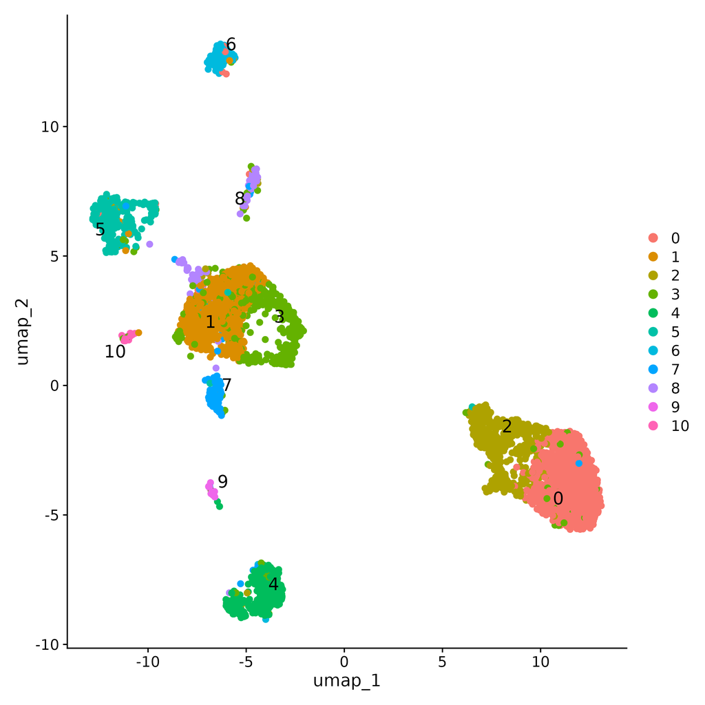

```r
# 设置默认的分析对象为 SCT 模态（经过 SCTransform 归一化的 RNA 数据）
DefaultAssay(cancer) <- "SCT"

# 在 PCA 降维空间的前30个主成分上构建 KNN 邻接图
cancer <- FindNeighbors(cancer, dims = 1:30)

# 基于邻接图进行细胞聚类（resolution 控制聚类粒度，algorithm=3 表示使用 Louvain 优化的 smart local moving 算法）
cancer <- FindClusters(cancer, resolution = 0.5, verbose = FALSE,algorithm = 3)

# 使用 UMAP 对细胞进行可视化展示
DimPlot(cancer, label = TRUE, repel = TRUE, reduction = "umap",label.size=5,pt.size=2)
```